## Tarea 1

Programa Experto en Inteligencia Artificial con Python  
ML3003 - Deep Learning  
Estudiante: Natalia Bonilla Villalobos.  
**Fundamentos Matemaáticos del Deep Learning**

# Menú

- Ejercicio 1
- Ejercicio 2
- Ejercicio 3
- Ejercicio 4
- Ejercicio 5
- Ejercicio 6
- Ejercicio 7
- Ejercicio 8
- Ejercicio 9
- Ejercicio 10

```python
import pandas as pd
import numpy as np
import matplotlib.pyplot as plt
from sklearn.model_selection import train_test_split
from tensorflow.keras.datasets import mnist
```

# Ejercicio 1

[5 puntos] Cree en **Python** usando *numpy* un tensor de $0D, 1D, 2D, 3D$ y uno $4D$.

↑ Volver al Menú

```python
tensor_0D = np.array(84) # escalar
print("="*27)
print("Tensor de 0D")
print("="*27)
print(tensor_0D, "\n")

tensor_1D = np.array([2, 4, 7, 45, -2]) # vector
print("="*27)
print("Tensor de 1D")
print("="*27)
print(tensor_1D, "\n")

tensor_2D = np.array([[2, 4, 7, 45, -2],[6, 8, 14, 23, -4]]) # matriz
print("="*27)
print("Tensor de 2D")
print("="*27)
print(tensor_2D, "\n")

tensor_3D = np.array([tensor_2D, tensor_2D, tensor_2D]) # coleccion de matrices
print("="*27)
print("Tensor de 3D")
print("="*27)
print(tensor_3D, "\n")

tensor_4D = np.array([tensor_3D, tensor_3D, tensor_3D]) # coleccion de tensores 3D
print("="*27)
print("Tensor de 4D")
print("="*27)
print(tensor_4D, "\n")
```

```
===========================
Tensor de 0D
===========================
84

===========================
Tensor de 1D
===========================
[ 2  4  7 45 -2]

===========================
Tensor de 2D
===========================
[[ 2  4  7 45 -2]
 [ 6  8 14 23 -4]]

===========================
Tensor de 3D
===========================
[[[ 2  4  7 45 -2]
  [ 6  8 14 23 -4]]

 [[ 2  4  7 45 -2]
  [ 6  8 14 23 -4]]

 [[ 2  4  7 45 -2]
  [ 6  8 14 23 -4]]]

===========================
Tensor de 4D
===========================
[[[[ 2  4  7 45 -2]
   [ 6  8 14 23 -4]]

  [[ 2  4  7 45 -2]
   [ 6  8 14 23 -4]]

  [[ 2  4  7 45 -2]
   [ 6  8 14 23 -4]]]


 [[[ 2  4  7 45 -2]
   [ 6  8 14 23 -4]]

  [[ 2  4  7 45 -2]
   [ 6  8 14 23 -4]]

  [[ 2  4  7 45 -2]
   [ 6  8 14 23 -4]]]


 [[[ 2  4  7 45 -2]
   [ 6  8 14 23 -4]]

  [[ 2  4  7 45 -2]
   [ 6  8 14 23 -4]]

  [[ 2  4  7 45 -2]
   [ 6  8 14 23 -4]]]]
```

# Ejercicio 2

[5 puntos] Imprima las dimensiones (shape) de la tabla de entrenamiento de `MNIST`. Esta es una tabla de dígitos escritos a mano y se usan para problemas de clasificación (problemas predictivos). Esta tabla viene con el paquete tensorflow y se obtiene como sigue:

`from tensorflow.keras.datasets import mnist`

`(x_train, y_train), (x_test, y_test) = mnist.load_data()`

↑ Volver al Menú

```python
(X_train, y_train), (X_test, y_test) = mnist.load_data()
```

```python
print("Usando X_train.shape:", X_train.shape) # Cuantos elementos hay en cada eje
print("Usando X_train.ndim:", X_train.ndim) # la cantidad de ejes
print("Usando y_train.shape:", y_train.shape)
print("Usando y_train.ndim:", y_train.ndim)
print("="*38)
print("Usando X_test.shape:", X_test.shape)
print("Usando X_test.ndim:", X_test.ndim)
print("Usando y_test.shape:", y_test.shape)
print("Usando y_test.ndim:", y_test.ndim)
```

```
Usando X_train.shape: (60000, 28, 28)
Usando X_train.ndim: 3
Usando y_train.shape: (60000,)
Usando y_train.ndim: 1
======================================
Usando X_test.shape: (10000, 28, 28)
Usando X_test.ndim: 3
Usando y_test.shape: (10000,)
Usando y_test.ndim: 1
```

# Ejercicio 3

↑ Volver al Menú

# Ejercicio 4

[10 puntos] La función de activación `rectifier (softplus)` es una operación que se aplica entrada por entrada de un vector, esta se define como sigue:  
$f(x) = ln (1 + e^x)$

Programe esta función en Python y después pruébela con el siguiente vector x.

`x = np.array[1, -9, -0.9, 45]`

↑ Volver al Menú

```python
x = np.array([1, -9, -0.9, 45])
x.shape
```

```
(4,)
```

```python
paso1 = (1 + np.e**x)
print(paso1)
print(paso1.shape)

paso2 = np.log(paso1)
print(paso2)
print(paso2.shape)
```

```
[3.71828183e+00 1.00012341e+00 1.40656966e+00 3.49342711e+19]
(4,)
[1.31326169e+00 1.23402190e-04 3.41153875e-01 4.50000000e+01]
(4,)
```

```python
# f(x) = ln( 1+e^x )
def func_softmax(x):
    fx = np.log(
                (1 + np.e**x) # fx = np.logaddexp(0, x)
                )
    # print(x.shape)
    return fx

func_softmax(x)
```

```
array([1.31326169e+00, 1.23402190e-04, 3.41153875e-01, 4.50000000e+01])
```

# Ejercicio 5

[10 puntos] Calcule "a mano":

- a) Suma de Matrices $2X2$:  
  $A$ = $\left[\begin{matrix} 2 & -3 \\ 1 & 4 \end{matrix}\right]$, $B$ = $\left[\begin{matrix} 5 & 2 \\ -1 & 0 \end{matrix}\right]$.  
  Calcular $7A + 2B$:

↑ Volver al Menú

$A + B$ = $\left[\begin{matrix} 2+5 & -3+2 \\ 1+(-1) & 4+0 \end{matrix}\right]$

$A+B$ = $\left[\begin{matrix} 7 & -1 \\ 0 & 4 \end{matrix}\right]$

- b) Resta de Matrices $2 X 2$:  
  $C$ = $\left[\begin{matrix} 3 & 1 \\ -2 & 5 \end{matrix}\right]$, $D$ = $\left[\begin{matrix} 4 & 0 \\ 2 & -1 \end{matrix}\right]$.

  Calcular $2C - 3D$:

↑ Volver al Menú

$A - B$ = $\left[\begin{matrix} 3-4 & 1-0 \\ -2 -2 & 5-(-1) \end{matrix}\right]$

$A - B$ = $\left[\begin{matrix} -1 & 1 \\ -4 & 6 \end{matrix}\right]$

- d) Operaciones con Matrices $3 X 3$:  
  $A$ = $\left[\begin{matrix} 2 & 1 & -3 \\ 4 & 0 & 2 \\ -1 & 3 & 5 \end{matrix}\right]$, $B$ = $\left[\begin{matrix} -1 & 2 & 1 \\ 5 & -2 & 0 \\ 3 & 1 & 4 \end{matrix}\right]$.

  Calcular:
  1. $A + 2B$.
  2. $4A - B$.
  3. $A * B$.

↑ Volver al Menú

1. $A + 2B$:

   $2B$ = $\left[\begin{matrix} -1*2 & 2*2 & 1*2 \\ 5*2 & -2*2 & 0*2 \\ 3*2 & 1*2 & 4*2 \end{matrix}\right]$

   $B$ = $\left[\begin{matrix} -2 & 4 & 2 \\ 10 & -4 & 0 \\ 6 & 2 & 8 \end{matrix}\right]$

   $A + B$ = $\left[\begin{matrix} 2 & 1 & -3 \\ 4 & 0 & 2 \\ -1 & 3 & 5 \end{matrix}\right]$ + $\left[\begin{matrix} -2 & 4 & 2 \\ 10 & -4 & 0 \\ 6 & 2 & 8 \end{matrix}\right]$

   $A + B$ = $\left[\begin{matrix} 2+(-2) & 1+4 & -3+2 \\ 4+10 & 0+(-4) & 2+0 \\ -1+6 & 3+2 & 5+8 \end{matrix}\right]$

   $A + B$ = $\left[\begin{matrix} 0 & 5 & -1 \\ 14 & -4 & 2 \\ 5 & 5 & 13 \end{matrix}\right]$
2. $4A - B$:

   $4A - B$ = $4*$ $\left[\begin{matrix} 2 & 1 & -3 \\ 4 & 0 & 2 \\ -1 & 3 & 5 \end{matrix}\right]$ - $\left[\begin{matrix} -1 & 2 & 1 \\ 5 & -2 & 0 \\ 3 & 1 & 4 \end{matrix}\right]$.

   $4A$ = $\left[\begin{matrix} 4*2 & 4*1 & 4*-3 \\ 4*4 & 4*0 & 4*2 \\ 4*-1 & 4*3 & 4*5 \end{matrix}\right]$

   $A$ = $\left[\begin{matrix} 8 & 4 & -12 \\ 16 & 0 & 8 \\ -4 & 12 & 20 \end{matrix}\right]$

   $A - B$ = $\left[\begin{matrix} 8 & 4 & -12 \\ 16 & 0 & 8 \\ -4 & 12 & 20 \end{matrix}\right]$ - $B$ = $\left[\begin{matrix} -1 & 2 & 1 \\ 5 & -2 & 0 \\ 3 & 1 & 4 \end{matrix}\right]$

   $A - B$ = $\left[\begin{matrix} 8-(-1) & 4-2 & -12-1 \\ 16-5 & 0-(-2) & 8-0 \\ -4-3 & 12-1 & 20-4 \end{matrix}\right]$

   $A - B$ = $\left[\begin{matrix} 9 & 2 & -13 \\ 11 & 2 & 8 \\ -7 & 11 & 16 \end{matrix}\right]$
- 3. $A * B$:

  $A * B$ = $\left[\begin{matrix} 2 & 1 & -3 \\ 4 & 0 & 2 \\ -1 & 3 & 5 \end{matrix}\right]$ * $\left[\begin{matrix} -1 & 2 & 1 \\ 5 & -2 & 0 \\ 3 & 1 & 4 \end{matrix}\right]$.

  $A * B$ = $\left[\begin{matrix} 2*(-1) & 1*2 & -3*1 \\ 4*5 & 0*(-2) & 2*0 \\ -1*3 & 3*1 & 5*4 \end{matrix}\right]$

  $A * B$ = $\left[\begin{matrix} -2 & 2 & -3 \\ 20 & 0 & 0 \\ -3 & 3 & 20 \end{matrix}\right]$

# Ejercicio 6

[20 puntos] Calcule "a mano" las siguientes derivadas. Muestre el procedimiento:

- a) $f(x) = 3x^2 + 2x - 1$
- b) $g(x) = $ $\sqrt{x}$ $+$ $\frac{1}{x}$
- c) $h(x) = e^2x * cos(x)$
- d) $j(x) =$ $\frac{x^2 +1 }{x-1}$

↑ Volver al Menú

- a) $f(x) = 3x^2 + 2x - 1$
  - Derivada de: $3x^2$ = $\frac{d}{dx}(3x^2)$ = $3*$ $\frac{d}{dx}(x^2)$
    - Derivada de: $\frac{d}{dx}(x^2)$ = $2x$, entonces: $3*2x = 6x$
  - Derivada de: $2x$ = $\frac{d}{dx}(2x)$ = $2*$ $\frac{d}{dx}(x)$
    - Derivada de: $\frac{d}{dx}(x)$ = $1$, entonces: $2*1 = 2$
  - Derivada de: $-1$ = $\frac{d}{dx}(-1)$ = 0 (la derivada de una constante es 0),  
    entonces: 0
  - Resultado:

    $f'(x)$ $= 6x + 2 $
- b) $g(x) = $ $\sqrt{x}$ $+$ $\frac{1}{x}$:
  - Derivada de: $\sqrt{x}$ = $\frac{1}{2\sqrt{x}}$
  - Derivada de: $\frac{1}{x}$ = $\frac{-1}{x^2}$
  - Resultado:

    $g'(x) = $ $\frac{1}{2\sqrt{x}}$ $+$ $\frac{-1}{x^2}$
- c) $h(x) = e^{2x} * cos(x)$  
  Se debe de usar la regla del producto  
  $(fg)' = f'g + fg'$
  - Derivada de: $e^{2x}$ = $2e^{2x}$ -> $f'$
  - Derivada de: $cos(x)$ = $ - sin(x)$ -> $g'$

  Sustituyendo la formula anteriorer quedaria:  
  $h'(x) =$ $2e^{2x}*cos(x) + e^{2x}*(-sin(x))$
  - Resultado:  
    $h'(x) = $ $e^{2x}(2*cos(x)-sin(x))$
- d) $j(x) =$ $\frac{x^2 +1 }{x-1}$  
  Se debe de usar la regla del cociente

  $\frac{d}{dx}(\frac{f(x)}{g(x)}) = $ $\frac{f'(x)g(x) - f(x)g'(x)}{[g(x)]^2}$

  Derivadas del Numerador
  - Derivada de: $x^2$ = $\frac{d}{dx}(x^2)$ = $2x$
  - Derivada de: $1$ = $\frac{d}{dx}(1)$ = $0$
  - Entonces: $f'(x) = 2x$

  Derivadas del Denominador
  - Derivada de: $x$ = $\frac{d}{dx}(x)$ = $1$
  - Derivada de: $-1$ = $\frac{d}{dx}(-1)$ = $0$
  - Entonces: $g'(x) = 1$

  Sustituyendo la rega del cociente quedaria:  
  Numerador:  
  $(2x)(x−1)−(x^2+1)(1)$  
  Denominador:  
  $(x-1)^2$
  - Resultado:

    $j'(x) =$ $\frac{2x(x−1)−(x^2+1)}{(x-1)^2}$

# Ejercicio 7

[10 puntos] Calcule "a mano" el gradiente de la siguiente función:  
$f(x, y, z) = 8x^5 + 2x cos(xz) + 25x^3yz^2$

↑ Volver al Menú

$\nabla$ -> Gradiente

$\nabla f = $ $[\frac{\partial f}{\partial x}, \frac{\partial f}{\partial y}, \frac{\partial f}{\partial z}]$

## Primero hacemos una derivada parcial respecto a $x$. -> $\frac{\partial f}{\partial x}$

===  
Derivada de $8x^5$ = $\frac{d}{dx}(x^n)$ = $nx^{n-1}$,

entonces sustituimos: $\frac{\partial}{\partial x}(8x^5)$ = $5 * 8x^{5-1}$ = $40x^4$

===  
Derivada de $2xcos(xz)$  
Usamos regla de producto.  
Derivada de $2x$ = 2.  
Derivada de $cos(xz)$ = $-sin(xz)$, como z es constante entonces, $-zsin(xz)$.

Aplicando la regla = $2cos(xz) - 2xz * sin(xz)$

===  
Derivada de $25x^3yz^2$, donde $y$ y $z$ son costantes.  
Derivada de $x^3$ es $3x^2$, entonces $25*3x^2yz^2$ = $75x^2yz^2$

Tenemos como resultado -> $\frac{\partial f}{\partial x} = $ $40x^4$ + $2cos(xz) - 2xz * sin(xz)$ + $75x^2yz^2$

## Segundo, hacemos una derivada parcial respecto a $y$. -> $\frac{\partial f}{\partial y}$

===  
Derivada de $8x^5$, no tiene y.  
constate = $0$.

===  
Derivada de $2xcos(xz)$, no tiene y.  
constate = $0$.

===  
Derivada de $25x^3yz^2$, donde $x^3$ y $z^2$ son costantes.  
Derivada de $y$ = 1, entonces $25*1x^3z^2$

Tenemos como resultado -> $\frac{\partial f}{\partial y} = $ $0$ + $0$ + $25x^3z^2$

## Tercero, hacemos una derivada parcial respecto a $z$. -> $\frac{\partial f}{\partial z}$

===  
Derivada de $8x^5$, no tiene z.  
constate = $0$.

===  
Derivada de $2xcos(xz)$  
constate = $2x$.  
Derivada de $cos(xz)$: $-sin(xz)$,  
entocces: $-2x^2sin(xz)$

===  
Derivada de $25x^3yz^2$, donde $x^3$ y $y$ son costantes.  
Derivada de $z^2$ = $2z$ = $2*25x^3yz$,

entonces $50x^3yz$,

Tenemos como resultado -> $\frac{\partial f}{\partial z} = $ $0$ $-2x^2sin(xz)$ + $50x^3yz$

$\nabla f(x, y, z) = $ $(40x^4$ + $2cos(xz) - 2xzsin(xz)$ + $75x^2yz^2, 25x^3z^2, -2x^2sin(xz)$ + $50x^3yz)$

```python
def resultadoFuncion(x):
    fx = 2*x**2 * np.cos(x) - 5*x # funcion sin derivar
    return fx

def resultadoDerivada(x):
    fdx = (4*x*np.cos(x)) + (- 2*x**2 * np.sin(x)) + (- 5)
    return fdx

def pendiente(X, n, fdx):
    pendiente = X - n * fdx
    return pendiente

def desensoGrad(x, n):
    # x = numero al azar
    fx0 = resultadoFuncion(x)
    x0 = x
    print(f"Primer Intervalo:\n"
          f"[X0, f(X0)]\n"
          f"[{x0}, {round(fx0,2)}]\n")

    # funcion matematica derivada
    fdx = resultadoDerivada(x0)
    X1 = pendiente(x0, n, fdx)
    fx1 = resultadoFuncion(X1)
    print(f"Segundo Intervalo:\n"
          f"[    X1, f(X1)]\n"
          f"[{round(X1, 3)}, {round(fx1,3)}]\n")

    fdx1 = resultadoDerivada(X1)
    X2 = pendiente(X1, n, fdx1)
    fx2 = resultadoFuncion(X2)
    print(f"Segundo Intervalo:\n"
          f"[    X2, f(X2)]\n"
          f"[{round(X2, 3)}, {round(fx2,3)}]\n")


desensoGrad(x = -1, n = 0.05)
```

```
Primer Intervalo:
[X0, f(X0)]
[-1, 6.08]

Segundo Intervalo:
[    X1, f(X1)]
[-0.726, 4.419]

Segundo Intervalo:
[    X2, f(X2)]
[-0.402, 2.311]
```

# Ejercicio 8

[10 puntos] Usando el algoritmo del Descenso de Gradiente encuentre "a mano" (puede utilizar excel) un mínimo local de la siguiente función en el intervalo $[-1; 4]$, use el punto de partida que considere adecuados. Luego grafique y verifique los resultados con código **Python**.

$f(x) = 9x^4 - 4x^3 + 8x^2$

↑ Volver al Menú

**La derivada de f (la pendiente). $f(x) = 9x^4 - 4x^3 + 8x^2$**

Como $\frac{d}{dx}(x^n)$ = $nx^{n-1}$, entonces:

- derivada de $9x^4$:  
  $\frac{d}{dx}(9x^4)$ = $4* 9x^{4-1}$ = $36x^3$
- derivada de $-4x^3$:  
  $\frac{d}{dx}(-4x^3)$ = $3* -4x^{3-1}$ = $- 12x^2$
- derivada de $8x^2$:  
  $\frac{d}{dx}(8x^2)$ = $8 * 2x$ = $16x$

Derivada: $f'(x) = 36x^3 - 12x^2 + 16x$

[figure not shown]

```
X =  [1.2]
Y =  [23.2704]
```

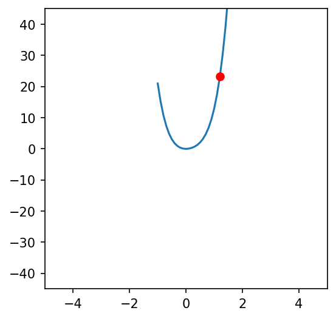

```python
figsize = (4, 4)
dpi = 150

def f(x):
    return 9*x**4 - 4*x**3 + 8*x**2


fig, ax = plt.subplots(1,1, figsize = figsize, dpi = dpi)

t1 = np.arange(-1.0, 4.0, 0.1)

ax.set_xlim(-5, 5)
ax.set_ylim(-45, 45)
ax.plot(t1, f(t1))

x = [1.2]
y = [f(x[0])]
ax.plot(x,y,'ro')

print("X = ", x)
print("Y = ", y)
```

```
Pendiente:  64.12799999999999
X =  [1.2, 1.007616]
Y =  [23.2704, 13.30755433921788]
```

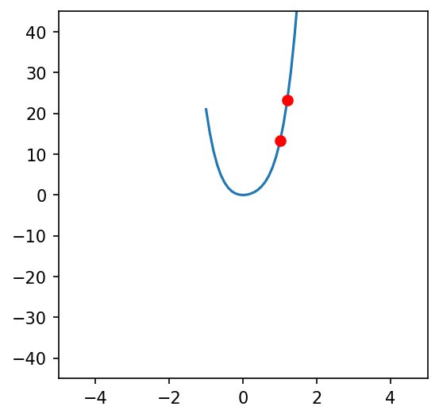

```python
# La derivada de f (la pendiente)
def df(x):
    return 36*x**3 - 12*x**2 + 16*x

pendiente = df(x[0])
print("Pendiente: ", pendiente)

eta = 0.003
x.append(x[0] - eta * pendiente)
y.append(f(x[0] - eta * pendiente))
print("X = ", x)
print("Y = ", y)


fig, ax = plt.subplots(1,1, figsize = figsize, dpi = dpi)
ax.set_xlim(-5, 5)
ax.set_ylim(-45, 45)
ax.plot(t1, f(t1))
ax.plot(x,y,'ro')
```

```
X =  [1.2, 1.007616, 0.8853144472952054]
Y =  [23.2704, 13.30755433921788, 9.023503783094519]
```

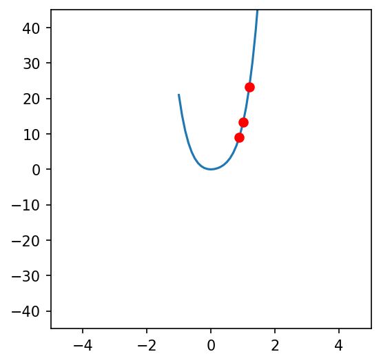

```python
x.append(x[1] - eta * df(x[1]))
y.append(f(x[1] - eta * df(x[1])))
print("X = ", x)
print("Y = ", y)

fig, ax = plt.subplots(1,1, figsize = figsize, dpi = dpi)
ax.set_xlim(-5, 5)
ax.set_ylim(-45, 45)
ax.plot(t1, f(t1))
ax.plot(x,y,'ro')
```

```
           X          Y
0   1.200000  23.270400
1   1.007616  13.307554
2   0.885314   9.023504
3   0.796095   6.666931
4   0.726208   5.190226
5   0.668973   4.185178
6   0.620640   3.460654
7   0.578897   2.915729
8   0.542222   2.492326
9   0.509563   2.154776
10  0.480162   1.880030
11  0.453458   1.652558
12  0.429024   1.461536
13  0.406529   1.299200
14  0.385709   1.159839
15  0.366354   1.039162
16  0.348290   0.933885
17  0.331376   0.841452
18  0.315493   0.759843
19  0.300541   0.687443
20  0.286435   0.622942
```

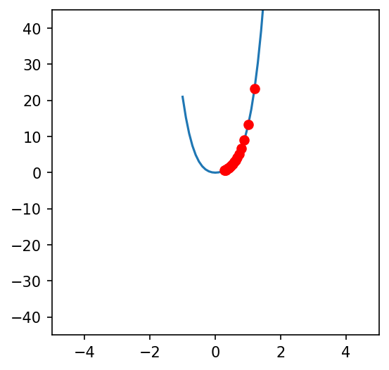

```python
eta = 0.003
x = [1.2]
y = [f(x[0])]
for i in range(20):
    x.append(x[i] - eta * df(x[i]))
    y.append(f(x[i] - eta * df(x[i])))

dt = pd.DataFrame({"X": x, "Y": y})
print(dt)

fig, ax = plt.subplots(1,1, figsize = figsize, dpi = dpi)
ax.set_xlim(-5, 5)
ax.set_ylim(-45, 45)
ax.plot(t1, f(t1))
ax.plot(x,y,'ro')
```

# Ejercicio 9

[10 puntos] Usando el algoritmo del Descenso de Gradiente encuentre "a mano" (puede utilizar excel) un mínimo local de la siguiente función, use el punto de partida que considere adecuados. Luego grafique y verifique los resultados con código **Python**.

$f(x, y) = x^3 + 3y - y^3 - 3x$

Gráficamente:

[figure not shown]

↑ Volver al Menú

$\nabla f = $ $[\frac{\partial f}{\partial x}, \frac{\partial f}{\partial y}]$

## Derivada parcial respecto a $x$. -> $\frac{\partial f}{\partial x}$

===  
Derivada de una potencia: $\frac{d}{dx}(x^n)$ = $nx^{n-1}$

Derivada de $x^3$ = $\frac{d}{dx}(x^3)$ = $3*1x*^{3-1}$ = $3x^2$  
Derivada de $3y$: no tiene x = $0$,  
Derivada de $y^3$: no tiene x = $0$,  
Derivada de $-3x$ = $\frac{d}{dx}(-3x)$ = $-3$

entonces: $3x^2$ + $0$ - $0$ - $3$

$\frac{\partial f}{\partial x}$ = $3x^2 - 3$

## Derivada parcial respecto a $y$. -> $\frac{\partial f}{\partial y}$

===  
Derivada de $x^3$: no tiene y = $0$  
Derivada de $3y$ = $3$,  
Derivada de $y^3$ = $\frac{d}{dx}(-y^3)$ = $-3*1y*^{3-1}$ = $-3y^2$ ,  
Derivada de $3x$: no tiene y = $0$

entonces: $0$ + $3$ - $3y^2$ - $0$

$\frac{\partial f}{\partial y}$ = $3 - 3y^2$

$\nabla f(x, y) =$ $(3x^2 - 3$, $3 - 3y^2 )$

[figure not shown]

```
          X         Y            Z
0  8.515000 -8.515000  1183.673982
1  7.442422 -7.442422   779.811574
2  6.626577 -6.626577   542.206719
3  5.982904 -5.982904   392.420390
4  5.460977 -5.460977   292.951605
5  5.028643 -5.028643   224.149250
6  4.664334 -4.664334   174.968635
7  4.352994 -4.352994   138.847947
8  4.083766 -4.083766   111.708487
9  3.848609 -3.848609    90.917894
```

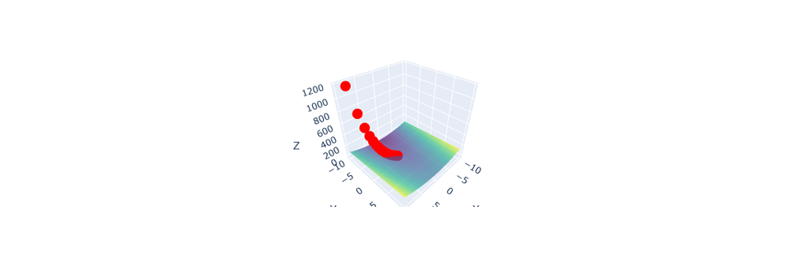

```python
import plotly.graph_objs as go
import plotly.express as px

def f(x,y):
    return x**3 + 3*y - y**3 - 3*x


def gradiente_f(x,y):
    return np.array([3*x**2 - 3, 3 - 3*y**2])


x = 10
y = -10
eta = 0.005
xi = np.array([x,y])

x = []
y = []
z = []

for i in range(60):
    xi = xi - eta * gradiente_f(xi[0],xi[1])
    x.append(xi[0])
    y.append(xi[1])
    z.append(f(xi[0],xi[1]))


dataF = pd.DataFrame({"X":x, "Y": y, "Z": z})
#Imprimimos en consola solamente 10
print(dataF.head(n = 10))


#Gráfico
fig = px.scatter_3d(dataF, x='X', y='Y', z='Z',color_discrete_sequence=["red"])

xdata = np.arange(-10, 10, 0.1)
ydata = np.arange(-10, 10, 0.1)
X,Y = np.meshgrid(xdata,ydata)
Z = X**2 + 3*Y
fig.add_trace(go.Surface(
    x = X,
    y = Y,
    z = Z,
    opacity = .7, showscale = False,
    colorscale='Viridis'
))

fig.show()
```

# Ejercicio 10

[10 puntos] Qué pasa si en el código visto en clase para optimizar una Función de Costo **(gradient_descent)** se usa un momentum (impulso) más pequeño a $0.7$? Qué pasa si en el código visto en clase para optimizar una Función de Costo **(gradient descent)** se usa un $\eta$ **(learning_rate)** de $10^{-9}$ ?

↑ Volver al Menú

```python
def gradient_descent(max_iterations,threshold,w_init,
                     obj_func,grad_func,extra_param = [],
                     learning_rate=0.05,momentum=0.8):
    w = w_init
    w_history = w
    f_history = obj_func(w,extra_param)
    delta_w = np.zeros(w.shape)
    i = 0
    diff = 1.0e10

    while  i<max_iterations and diff>threshold:
        delta_w = -learning_rate*grad_func(w,extra_param) + momentum*delta_w
        w = w+delta_w

        # Almacena la historia of w y f
        w_history = np.vstack((w_history,w))
        f_history = np.vstack((f_history,obj_func(w,extra_param)))

        i+=1
        diff = np.absolute(f_history[-1]-f_history[-2])

    return w_history,f_history

# w es un vector de pesos y xy el vetor fila de datos (train_data, target)
def grad_mse(w,xy):
    (x,y) = xy
    (rows,cols) = x.shape

    # Calcula la salida
    o = np.sum(x*w,axis=1)
    diff = y-o
    diff = diff.reshape((rows,1))
    diff = np.tile(diff, (1, cols))
    grad = diff*x
    grad = -np.sum(grad,axis=0)
    return grad


#  w es un vector de pesos y xy el vector fila de datos (train_data, target)
def mse(w,xy):
    (x,y) = xy

    # Calcula la salida usando el mse
    o = np.sum(x*w,axis=1)
    mse = np.sum((y-o)*(y-o))
    mse = mse/2
    return mse
```

```python
# Para ilustrar el descenso de gradiente en un problema de clasificación,
#hemos elegido los conjuntos de datos de dígitos incluidos en sklearn.datasets.
# Cargamos los datos
datos = pd.read_csv("digitos_AMano.csv", header=0, index_col=None, decimal=".", sep = ";")
print(datos.shape)
datos.head()
```

```
(360, 65)
```

|  | pixel_0_0 | pixel_0_1 | pixel_0_2 | pixel_0_3 | pixel_0_4 | pixel_0_5 | pixel_0_6 | pixel_0_7 | pixel_1_0 | pixel_1_1 | ... | pixel_6_7 | pixel_7_0 | pixel_7_1 | pixel_7_2 | pixel_7_3 | pixel_7_4 | pixel_7_5 | pixel_7_6 | pixel_7_7 | digito |
| --- | --- | --- | --- | --- | --- | --- | --- | --- | --- | --- | --- | --- | --- | --- | --- | --- | --- | --- | --- | --- | --- |
| 0 | 0.0 | 0.0 | 5.0 | 13.0 | 9.0 | 1.0 | 0.0 | 0.0 | 0.0 | 0.0 | ... | 0.0 | 0.0 | 0.0 | 6.0 | 13.0 | 10.0 | 0.0 | 0.0 | 0.0 | 0 |
| 1 | 0.0 | 0.0 | 0.0 | 12.0 | 13.0 | 5.0 | 0.0 | 0.0 | 0.0 | 0.0 | ... | 0.0 | 0.0 | 0.0 | 0.0 | 11.0 | 16.0 | 10.0 | 0.0 | 0.0 | 1 |
| 2 | 0.0 | 0.0 | 1.0 | 9.0 | 15.0 | 11.0 | 0.0 | 0.0 | 0.0 | 0.0 | ... | 0.0 | 0.0 | 0.0 | 1.0 | 10.0 | 13.0 | 3.0 | 0.0 | 0.0 | 0 |
| 3 | 0.0 | 0.0 | 0.0 | 0.0 | 14.0 | 13.0 | 1.0 | 0.0 | 0.0 | 0.0 | ... | 0.0 | 0.0 | 0.0 | 0.0 | 1.0 | 13.0 | 16.0 | 1.0 | 0.0 | 1 |
| 4 | 0.0 | 0.0 | 3.0 | 13.0 | 11.0 | 7.0 | 0.0 | 0.0 | 0.0 | 0.0 | ... | 0.0 | 0.0 | 0.0 | 2.0 | 12.0 | 13.0 | 4.0 | 0.0 | 0.0 | 0 |

5 rows × 65 columns

```python
Y = datos["digito"].ravel()
X = datos.drop(columns=["digito"]).to_numpy()
```

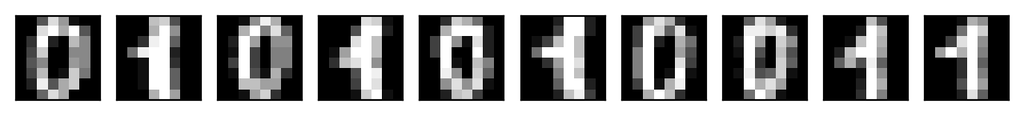

```python
# Graficas imágenes de los dígitos
fig, ax = plt.subplots(nrows=1, ncols=10, figsize = (8,4), dpi = 200,
                       subplot_kw=dict(xticks=[], yticks=[]))
for i in np.arange(10):
    ax[i].imshow(X[i,:].reshape(8,8),cmap=plt.cm.gray)
```

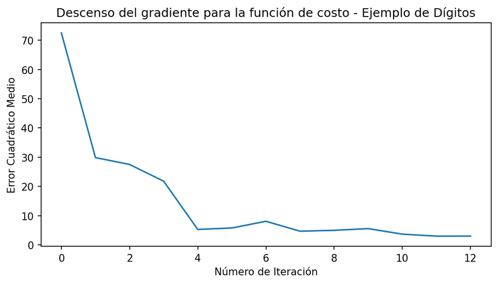

```python
# Separa train y test set
x_train, x_test, y_train, y_test = train_test_split(
                        X, Y, test_size=0.2, random_state=10)

# Agrega la columna de unos de al regresión (bias) en train and test
x_train = np.hstack((np.ones((y_train.size,1)),x_train))
x_test  = np.hstack((np.ones((y_test.size,1)),x_test))

# Inicializa los pesos y llama a gradient_descent
rand = np.random.RandomState(19)
w_init = rand.uniform(-1,1,x_train.shape[1])*.000001
w_history,mse_history = gradient_descent(100,0.1,w_init,
                              mse,grad_mse,(x_train,y_train),
                             learning_rate=1e-6,momentum=0.7)

# Grafica el MSE
fig, ax = plt.subplots(1,1, figsize = (8, 4), dpi = dpi)
ax.plot(np.arange(mse_history.size),mse_history)
ax.set_xlabel('Número de Iteración')
ax.set_ylabel('Error Cuadrático Medio')
ax.set_title('Descenso del gradiente para la función de costo - Ejemplo de Dígitos')
```

1. Qué pasa si en el código visto en clase para optimizar una Función de Costo **(gradient_descent)** se usa un momentum (impulso) más pequeño a $0.7$?
   - Si se usan un números menor a $0.7$ (siempre en el intervalo [0, 1]) la curva del descenso del gradiente se va suavizando, no muestra oscilaciones y es mas estable. El error baja de manera continua, pero parece que necesita más iteraciones para llegar al mínimo, entonces la convergencia puede ser un poco mas lenta, o sea, puede tardar mas en llegar al minimo.

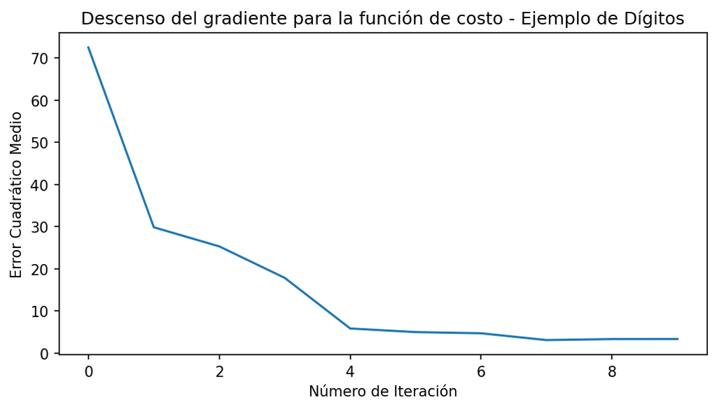

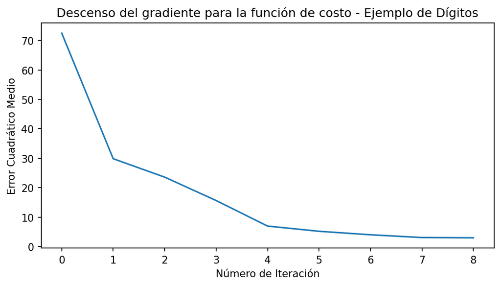

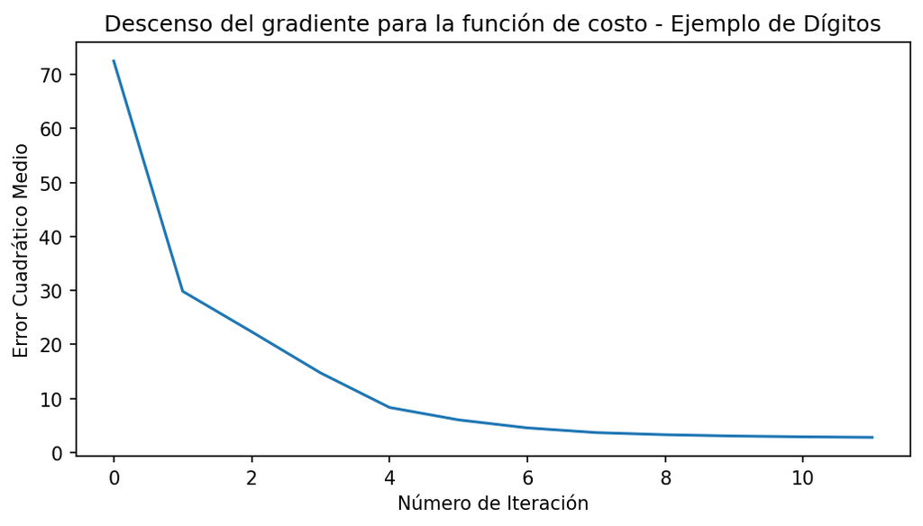

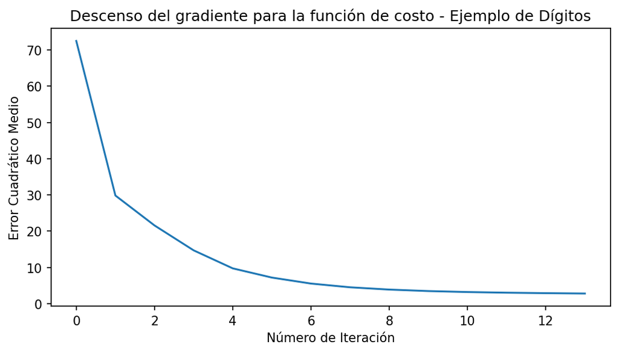

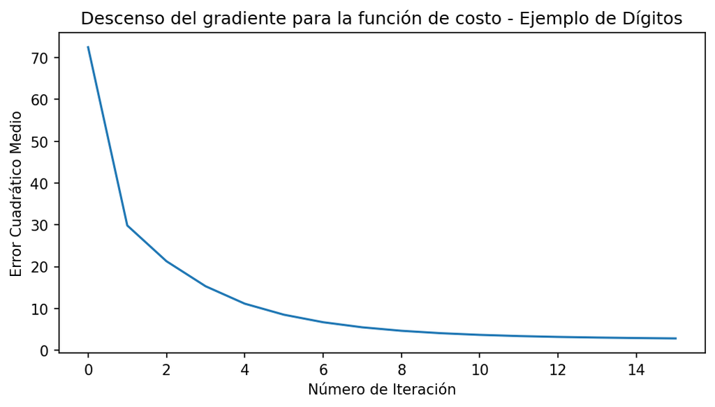

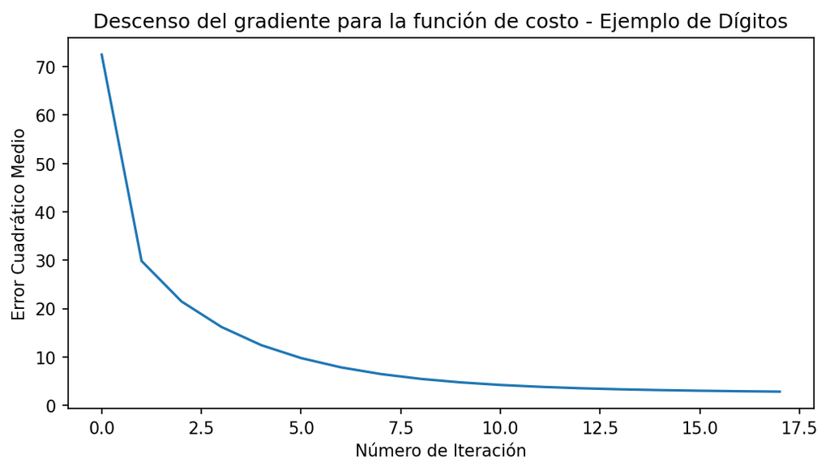

```python
# ----------------------------------- momentum = 0.6 -----------------------------------
w_history,mse_history = gradient_descent(100,0.1,w_init,
                              mse,grad_mse,(x_train,y_train),
                             learning_rate=1e-6,momentum=0.6)

# Grafica el MSE
fig, ax = plt.subplots(1,1, figsize = (8, 4), dpi = dpi)
ax.plot(np.arange(mse_history.size),mse_history)
ax.set_xlabel('Número de Iteración')
ax.set_ylabel('Error Cuadrático Medio')
ax.set_title('Descenso del gradiente para la función de costo - Ejemplo de Dígitos')


# ----------------------------------- momentum = 0.5 -----------------------------------
w_history,mse_history = gradient_descent(100,0.1,w_init,
                              mse,grad_mse,(x_train,y_train),
                             learning_rate=1e-6,momentum=0.5)

# Grafica el MSE
fig, ax = plt.subplots(1,1, figsize = (8, 4), dpi = dpi)
ax.plot(np.arange(mse_history.size),mse_history)
ax.set_xlabel('Número de Iteración')
ax.set_ylabel('Error Cuadrático Medio')
ax.set_title('Descenso del gradiente para la función de costo - Ejemplo de Dígitos')

# ----------------------------------- momentum = 0.4 -----------------------------------
w_history,mse_history = gradient_descent(100,0.1,w_init,
                              mse,grad_mse,(x_train,y_train),
                             learning_rate=1e-6,momentum=0.4)

# Grafica el MSE
fig, ax = plt.subplots(1,1, figsize = (8, 4), dpi = dpi)
ax.plot(np.arange(mse_history.size),mse_history)
ax.set_xlabel('Número de Iteración')
ax.set_ylabel('Error Cuadrático Medio')
ax.set_title('Descenso del gradiente para la función de costo - Ejemplo de Dígitos')

# ----------------------------------- momentum = 0.3 -----------------------------------
w_history,mse_history = gradient_descent(100,0.1,w_init,
                              mse,grad_mse,(x_train,y_train),
                             learning_rate=1e-6,momentum=0.3)

# Grafica el MSE
fig, ax = plt.subplots(1,1, figsize = (8, 4), dpi = dpi)
ax.plot(np.arange(mse_history.size),mse_history)
ax.set_xlabel('Número de Iteración')
ax.set_ylabel('Error Cuadrático Medio')
ax.set_title('Descenso del gradiente para la función de costo - Ejemplo de Dígitos')

# ----------------------------------- momentum = 0.2 -----------------------------------
w_history,mse_history = gradient_descent(100,0.1,w_init,
                              mse,grad_mse,(x_train,y_train),
                             learning_rate=1e-6,momentum=0.2)

# Grafica el MSE
fig, ax = plt.subplots(1,1, figsize = (8, 4), dpi = dpi)
ax.plot(np.arange(mse_history.size),mse_history)
ax.set_xlabel('Número de Iteración')
ax.set_ylabel('Error Cuadrático Medio')
ax.set_title('Descenso del gradiente para la función de costo - Ejemplo de Dígitos')


# ----------------------------------- momentum = 0.1 -----------------------------------
w_history,mse_history = gradient_descent(100,0.1,w_init,
                              mse,grad_mse,(x_train,y_train),
                             learning_rate=1e-6,momentum=0.1)


# Grafica el MSE
fig, ax = plt.subplots(1,1, figsize = (8, 4), dpi = dpi)
ax.plot(np.arange(mse_history.size),mse_history)
ax.set_xlabel('Número de Iteración')
ax.set_ylabel('Error Cuadrático Medio')
ax.set_title('Descenso del gradiente para la función de costo - Ejemplo de Dígitos')
```

2. Qué pasa si en el código visto en clase para optimizar una Función de Costo **(gradient descent)** se usa un $\eta$ **(learning_rate)** de $10^{-9}$
- Si vemos el Error Cuadrático Medio desciende muy poco va de 72.5 -> 72.43, descendió aprox 0.07. Como el Learning_rate, o sea, el tamaño del paso, es muy muy pequeño el paso que se da en cada iteración es mínima, por lo que no tenemos oscilación y la convergencia (o sea, lo que tardar en llegar al minimo) es lentísima. Esto quiere decir que para acercarse al mínimo necesitaría muchas mas iteraciones.

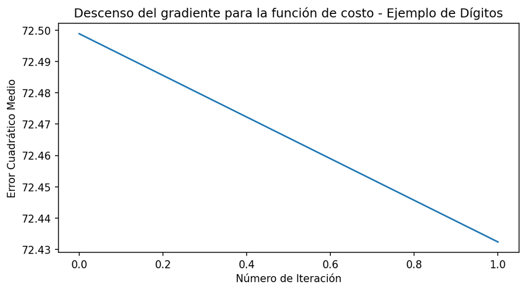

```python
# ----------------------------------- momentum = 0.7 y learning_rate=1e-9 -----------------------------------
w_history,mse_history = gradient_descent(100,0.1,w_init,
                              mse,grad_mse,(x_train,y_train),
                             learning_rate=1e-9,momentum=0.7)

# Grafica el MSE
fig, ax = plt.subplots(1,1, figsize = (8, 4), dpi = dpi)
ax.plot(np.arange(mse_history.size),mse_history)
ax.set_xlabel('Número de Iteración')
ax.set_ylabel('Error Cuadrático Medio')
ax.set_title('Descenso del gradiente para la función de costo - Ejemplo de Dígitos')
```